# Reproducing analyses from the Cochrane DTA handbook in MetaBayesDTA v2.0

# 6 Comparing index tests in the bivariate model, 9.4.7.3 Example 3: CT versus MRI for the diagnosis of coronary artery disease

In practical terms this example is no different from the previous two, so the procedure in section 4 can be followed. The dataset is *schuetz.csv*.

## 6.1 Format the dataset

In this example it is especially important to rename the index test variable from **Test** to **Test.cat**. If this is not done, the HSROC curve will not be produced.

## 6.2 Analyse the data

Follow the instructions for meta-regression in section 4.

# 7 Imperfect reference standard, 10.8 Latent class meta-analysis

## 7.1 Format the dataset

The data in this example are provided only in the R script *rjags - LC meta-analysis model (11.8).R*, shown below, where **n11** is **TP**, **n10** is **FP**, **n01** is **FN**, and **n00** is **TN**. They can be typed by hand into a CSV file, though great care must be taken to avoid a transcription error when using this method. There are various alternatives in which the data can be copied without resorting to painstaking typing, one of which is now described.

Open the script in RStudio and run these lines.

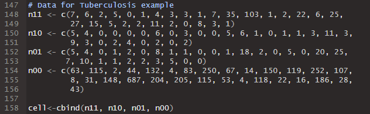

Run the command **view(cell)**, then right click on the data and **Select All**. When the dataset is highlighted, copy it to the clipboard via **Ctrl+C**.

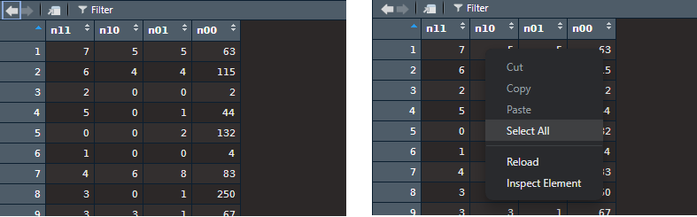

Open a blank spreadsheet and paste the dataset in. It should have maintained its structure, i.e. the numbers should each be in their own cell.

[figure not shown]

Manually edit the spreadsheet until it is in the format required by MetaBayesDTA. Dummy values can be entered for **author** and **year**. The reference standard must be specified in a column named **reference.cat** and must have the same value in each trial, which is “Culture” in the screenshot.

[figure not shown]

## 7.2 Analyse the data

Select **Latent class meta-analysis** under **Imperfect gold standard**, and then enter the name of the index test if desired.

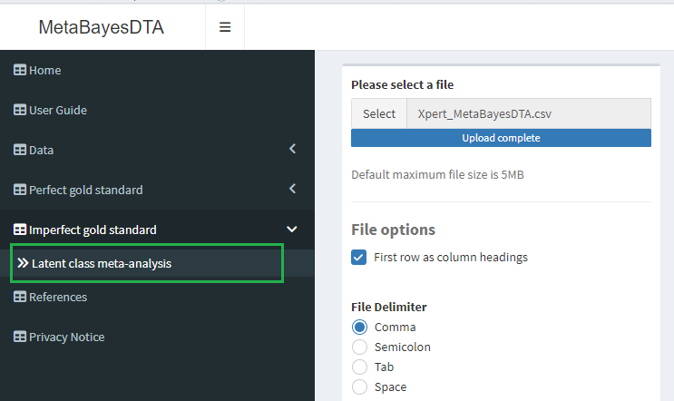

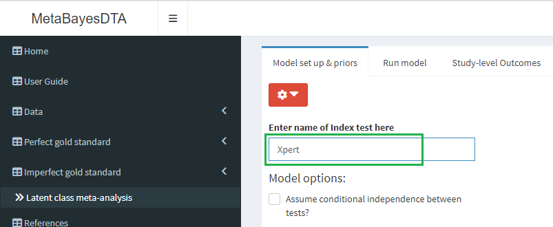

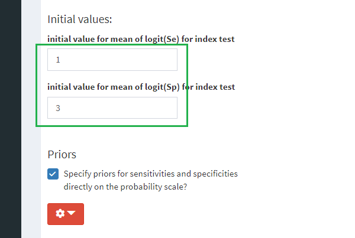

Then narrow the central 95% range of the prior distributions of sensitivity to the interval [0.5, 0.8] by selecting the drop-down menu

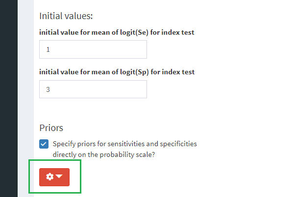

and editing the range for the reference test

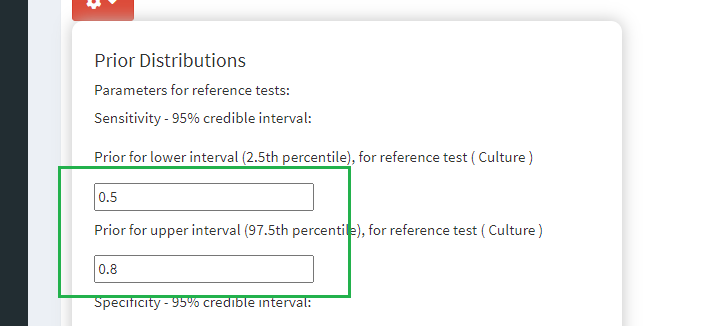

and the index test.

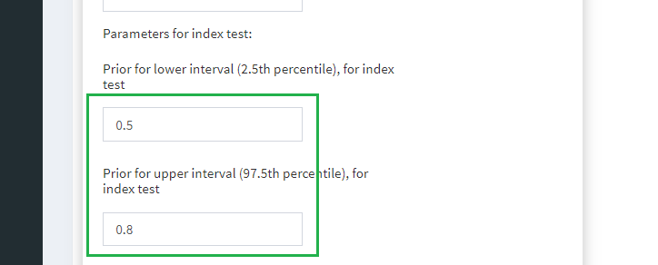

When the model has run, the HSROC curve will be squashed because the specificity values are clustered close to 1. To improve the display, select **set x and y axis limits to (0,1)** from the drop-down menu.

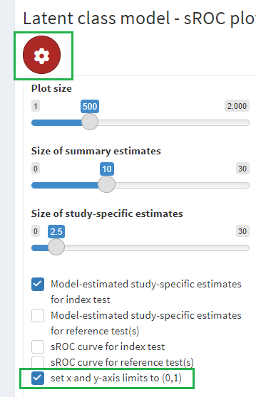

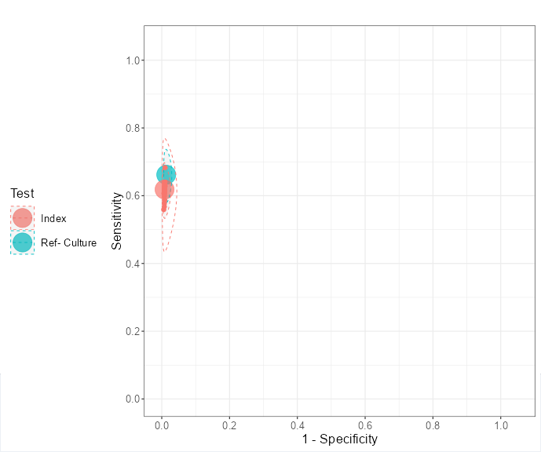

## 7.3 Compare the parameters

The parameter table can be found in section 10.8, page 76 of the handbook chapter 10.

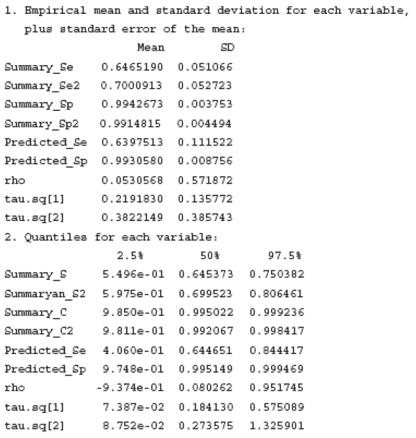

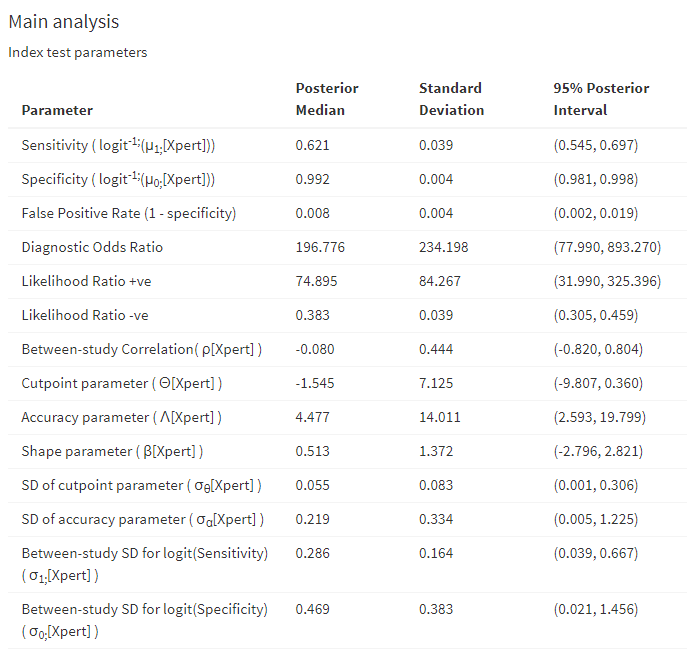

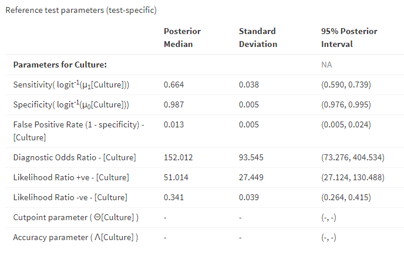

# 8 Appendix

Not all of the output given in the Cochrane handbook is provided by MetaBayesDTA. In most cases, however, the missing parameter estimates can be estimated from MetaBayesDTA output. The derivation of these estimates is described below.

## 8.1 Variances

This sections refers to $\sigma_A^2$ and $\sigma_B^2$ in the bivariate model, and $\sigma_\alpha^2$ and $\sigma_\theta^2$ in the HSROC model.

Assuming the parameter $\sigma^2$ has distribution satisfying

$$\sigma^2 (n-1) / \sigma_m^2 \sim \chi^2_{n-1}$$

where $E(\sigma^2) = \sigma_m^2$ and $n$ is the number of trials, its standard deviation can be estimated by

$$SD(\sigma^2) = \sqrt{2} \sigma_m^2 / \sqrt{n-1}.$$

This follows immediately from the distributional assumption, because $Var(\chi^2_{n-1}) = 2(n-1)$.

## 8.2 Correlations

This sections refers to $\rho$ in the bivariate model.

The standard deviation of the correlation $\rho$ between two parameters can be estimated as

$$(1 - r^2) / \sqrt{n-1}$$

where $r$ is an estimate of their correlation and $n$ is the number of trials. Note that a confidence interval for $\rho$ is not required, only a point estimate $r$.

## 8.3 Difference of two means

This sections refers to $\nu_A$ and $\nu_B$ in the bivariate model with a covariate.

In 9.4.6.3 example 1 the handbook gives parameter estimates for $\mu$ and $\nu$ (omitting the subscript $A$ or $B$), whereas MetaBayesDTA gives estimates for the mean logit sensitivity (and specificity) within the two subgroups, namely $\mu_1 = \mu$ for group 1 (CCP1) and $\mu_2 = \mu + \nu$ for group 2 (CCP2). This subsection describes how to obtain a point estimate, standard deviation and 95% posterior interval for $\nu$.

Let $n_i$ be the number of trials in group $i$ with total number of trials $n = n_1 + n_2$.

A point estimate of $\nu$ is $\hat{\nu} = \hat{\mu}_2 - \hat{\mu}_1$, and a 95% posterior interval is

$$\hat{\nu} \pm 1.96 SD(\nu).$$

The standard deviation of $\nu$ can be estimated by

$$SD(\nu) = \hat{\sigma} \sqrt{n} / \sqrt{n_1 n_2},$$

with the details as follows. Focusing on the marginal distribution of sensitivity or specificity, the model is described by $Y_i \sim N(\mu + \nu Z_i, \sigma^2)$, where $Z_i = 0$ in group 1 and $Z_i = 1$ in group 2. Writing the model in its usual matrix form

$$E(Y) = X \beta \hspace{10pt} \text{and} \hspace{10pt} Var(Y) = \sigma^2 I_n,$$

where $\beta = (\mu, \nu)^T$, the parameter estimates (posterior medians) are approximately $\hat{\beta} = (X^T X)^{-1} X^T y$ with covariance matrix

$$Var(\beta) = \sigma^2 (X^T X)^{-1}.$$

The design matrix $X$ is given by

$$X^T = \begin{pmatrix} 1 & ... & 1 & 1 & ... & 1 \\
0 & ... & 0 & 1 & ... & 1 \end{pmatrix}$$

where there are $n$ $1$s in the first row, and $n_1$ $0$s and $n_2$ $1$s in the second. Therefore

$$X^T X = \begin{pmatrix} n & n_2 \\
n_2 & n_2 \end{pmatrix}$$

and

$$(X^T X)^{-1} = \frac{1}{n_1 n_2} \begin{pmatrix} n_2 & -n_2 \\
-n_2 & n \end{pmatrix}.$$

Thus

$$Var(\beta) = \frac{\sigma^2}{n_1 n_2} \begin{pmatrix} n_2 & -n_2 \\
-n_2 & n \end{pmatrix}$$

and it follows that

$$SD(\nu) = \sigma \sqrt{n} / \sqrt{n_1 n_2}.$$